# FINAL PROJECT - DRUG CONSUMPTION ANALYSIS

#### Corrélations importantes liées à la consommation de cannabis

Sur l'ensemble des colonnes du dataset (démographie, personnalité et autres drogues) :

On remarque que ce sont d'autres drogues qui sont le plus corrélées à la consommation de cannabis.

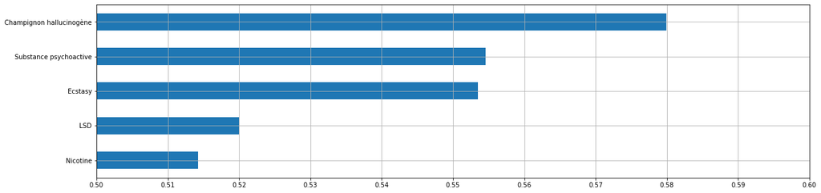

```python
cannabis_corr = data.corr()['Cannabis']
filt = cannabis_corr.apply(lambda x : abs(x) > 0.5 and x != 1)
abs(cannabis_corr[filt]).sort_values().plot.barh(figsize=(20,5), xlim=(0.5,0.6),
                                                    xticks=np.linspace(0.5,0.6,11),
                                                   grid=True)
plt.show()
```

Uniquement sur les colonnes caractéristiques (démographie et personnalité, en excluant les autres drogues) :

On remarque cette fois que la recherche de sensation, l'âge et l'ouverture à l'expérience sont les traits de personnalité les plus correlées à la consommation de cannabis.

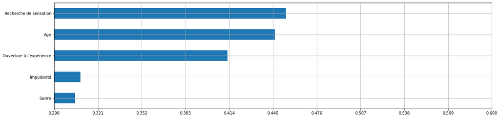

```python
cannabis_corr = data[col_démographie+col_personnalité+ ['Cannabis']].corr()['Cannabis']
filt = cannabis_corr.apply(lambda x : abs(x) > 0.29 and x != 1)
abs(cannabis_corr[filt]).sort_values().plot.barh(figsize=(20,5), xlim=(0.29,0.6),
                                                    xticks=np.linspace(0.29,0.6,11),
                                                   grid=True)
plt.show()
```

#### Corrélations importantes liées à la consommation d'alcool

Sur l'ensemble des colonnes du dataset (démographie, personnalité et autres drogues) :

On remarque que ce sont les variables Education, Cafféine et recherche de sensation les plus correlées à la consommation d'alcool.

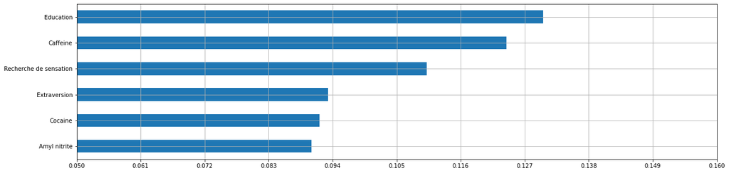

```python
alcool_corr = data.corr()['Alcool']
filt = alcool_corr.apply(lambda x : abs(x) > 0.09 and x != 1)
abs(alcool_corr[filt]).sort_values().plot.barh(figsize=(20,5),  xlim=(0.05,0.16),
                                                    xticks=np.linspace(0.05,0.16,11),
                                                   grid=True)
plt.show()
```

Uniquement sur les colonnes caractéristiques (démographie et personnalité, en excluant les autres drogues) :

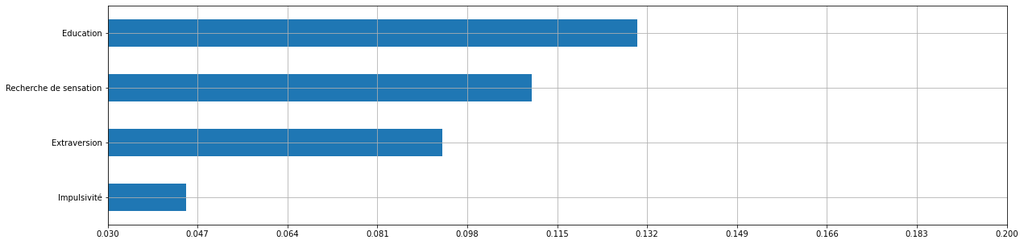

```python
alcool_corr = data[col_démographie+col_personnalité+ ['Alcool']].corr()['Alcool']
filt = alcool_corr.apply(lambda x : abs(x) > 0.035 and x != 1)
abs(alcool_corr[filt]).sort_values().plot.barh(figsize=(20,5), xlim=(0.03,0.2),
                                                    xticks=np.linspace(0.03,0.2,11),
                                                   grid=True)
plt.show()
```

#### Corrélations importantes liées à la recherche de sensation

Ici, on cherche à savoir quelles drogues sont les plus liées aux personnes qui recherchent des sensations.

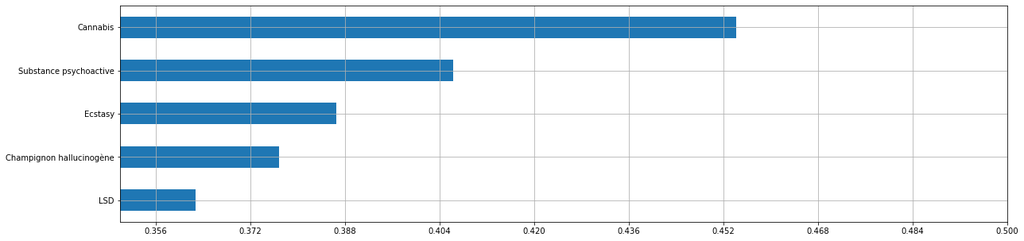

```python
cor = data[col_drogue +['Recherche de sensation']].corr()['Recherche de sensation']
filt = cor.apply(lambda x : abs(x) > 0.35 and x != 1)
abs(cor[filt]).sort_values().plot.barh(figsize=(20,5),  xlim=(0.35,0.5),
                                                    xticks=np.linspace(0.34,0.5,11),
                                                   grid=True)
plt.show()
```

#### Corrélations importantes liées à l'ouverture à l'expérience

Ici, on cherche à savoir quelles drogues sont les plus liées aux personnes qui sont ouvertes à l'expérience.

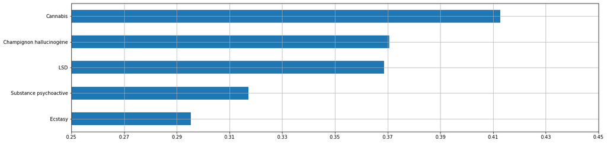

```python
cor = data[col_drogue +['Ouverture à l\'expérience']].corr()['Ouverture à l\'expérience']
filt = cor.apply(lambda x : abs(x) > 0.25 and x != 1)
abs(cor[filt]).sort_values().plot.barh(figsize=(20,5),  xlim=(0.25,0.45),
                                                    xticks=np.linspace(0.25,0.45,11),
                                                   grid=True)
plt.show()
```

# 3_Data Modeling

# Prédictions

Penser à faire des ROC curves pour comparer les modèles

```python
from sklearn.model_selection import GridSearchCV, train_test_split, cross_val_score,RepeatedStratifiedKFold
from sklearn.preprocessing import StandardScaler
from sklearn.metrics import accuracy_score, f1_score, confusion_matrix, roc_curve, auc
from sklearn import metrics
from sklearn.linear_model import LogisticRegression
```

### Data preprocessing

```python
def preprocessing_inputs(data, drogue):
    data = data.copy()
    #Séparation en X et y
    X = data.drop(drogue, axis=1)
    y = data[drogue]
    #Séparation en training et testing
    X_train, X_test, y_train, y_test = train_test_split(X, y, test_size=0.3, random_state=1)
    # Scaling
    scaler = StandardScaler()
    scaler.fit(X_train)
    X_train = pd.DataFrame(scaler.transform(X_train), index=X_train.index, columns=X_train.columns)
    X_test = pd.DataFrame(scaler.transform(X_test), index=X_test.index, columns=X_test.columns)
    return X_train, X_test, y_train, y_test
```

Fonction qui renvoie la précision, le recall, le f1-score et la matrice de confusion :

```python
def report_performance(model):
    model_pred = model.predict(X_test)
    cm=confusion_matrix(y_test, model_pred)
    sns.heatmap(cm, annot=True, fmt='d',cmap='Reds');
    print(metrics.classification_report(y_test, model_pred))
```

### Analyse de la consommation de cannabis

```python
oh_data['Cannabis'].sum()/1885
```

```
0.3411140583554377
```

```python
oh_data['Alcool'].sum()/1885
```

```
0.6689655172413793
```

```python
X_train, X_test, y_train, y_test=preprocessing_inputs(oh_data, 'Cannabis')
```

#### Standardisation pour la Régression logistique et KNN

```python
X_train_scale = X_train.copy()
X_test_scale = X_test.copy()

scale = StandardScaler()

X_train_scale = scale.fit_transform(X_train_scale)
X_test_scale = scale.fit_transform(X_test_scale)
```

### Regression Logistique

Avec valeurs standardisées

```
              precision    recall  f1-score   support

           0       0.80      0.88      0.84       367
           1       0.72      0.59      0.65       197

    accuracy                           0.78       564
   macro avg       0.76      0.73      0.74       564
weighted avg       0.77      0.78      0.77       564
```

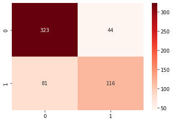

```python
LR=LogisticRegression(penalty='l1', solver='saga', multi_class='multinomial')
LR.fit(X_train_scale, y_train)
LR_pred=LR.predict(X_test_scale)
report_performance(LR)

LR_pred_proba=LR.predict_proba(X_test_scale)[:,1]
fpr_LR, tpr_LR, thresholds_LR = roc_curve(y_test, LR_pred)
roc_auc_LR = auc(fpr_LR, tpr_LR)
```

Avec valeurs non standardisées

```
              precision    recall  f1-score   support

           0       0.80      0.88      0.84       367
           1       0.72      0.59      0.65       197

    accuracy                           0.78       564
   macro avg       0.76      0.73      0.74       564
weighted avg       0.77      0.78      0.77       564
```

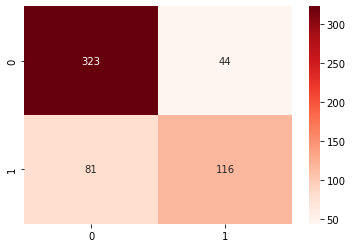

```python
LR=LogisticRegression(penalty='l1', solver='saga', multi_class='multinomial')
LR.fit(X_train, y_train)
LR_pred=LR.predict(X_test)
report_performance(LR)
```

Même résultat donc on utilisera uniquement les valeurs non standardisées

```python
#méthode pour avoir uniquement le f1_score
f1_score(y_test, LR_pred)
```

```
0.649859943977591
```

```python
#autre méthode

metrics_list = ['f1','accuracy','precision']
scores = pd.DataFrame(index=metrics_list, columns=['score'])

#implementation de cross_val_score pour chaque métrique
for metric in metrics_list:
    score= cross_val_score(LR, X_train, y_train, scoring=metric).mean()
    scores.loc[metric] = [score]
scores
```

|  | score |
| --- | --- |
| f1 | 0.65079 |
| accuracy | 0.779883 |
| precision | 0.711044 |

##### Grid search

```python
#sources :
#https://medium.com/@data.science.enthusiast/logistic-regression-tune-hyperparameters-python-code-fintech-does-it-bring-any-value-619e172565e6
#https://machinelearningmastery.com/hyperparameters-for-classification-machine-learning-algorithms/

#lbfgs is an overall best performer compared to other methods and is memory efficient. You may encounter convergence issues though.
#saga is also suitable for very large datasets, you can choose this solver for sparse multinomial logistic regression.

# modèle et hyper paramètres
model = LogisticRegression()
solvers = ['lbfgs', 'saga']
penalty = ['none', 'l1', 'l2']
c_values = [100, 10, 1.0, 0.1, 0.01]
# Grid search
grid = dict(solver=solvers,penalty=penalty,C=c_values)
cv = RepeatedStratifiedKFold(n_splits=10, n_repeats=3, random_state=1)
LR_gs = GridSearchCV(estimator=model, param_grid=grid, n_jobs=-1, cv=cv, scoring='f1',error_score=0)
LR_grid_result = LR_gs.fit(X_train_scale, y_train)
# Résultats
print('\nBest params:\n', LR_grid_result.best_params_)
print('Train score: %.3f' % LR_grid_result.best_score_)
print('Test score: %.3f' % LR_grid_result.score(X_test_scale, y_test))
```

```
Best params:
 {'C': 100, 'penalty': 'none', 'solver': 'lbfgs'}
Train score: 0.642
Test score: 0.670
```

### Decision Tree

```
              precision    recall  f1-score   support

           0       0.82      0.80      0.81       367
           1       0.64      0.69      0.66       197

    accuracy                           0.76       564
   macro avg       0.73      0.74      0.74       564
weighted avg       0.76      0.76      0.76       564
```

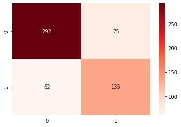

```python
from sklearn.tree import DecisionTreeClassifier
DT=DecisionTreeClassifier(criterion='gini',max_depth=4,random_state=0)
DT.fit(X_train, y_train.ravel())
report_performance(DT)
```

##### Grid Search

```python
# modèle et hyper paramètres
model=DecisionTreeClassifier()
grid = {
    'max_depth': [2, 3, 5, 10, 20],
    'min_samples_leaf': [5, 10, 20, 50, 100],
    'criterion': ["gini", "entropy"]}
# Grid search
cv = RepeatedStratifiedKFold(n_splits=10, n_repeats=3, random_state=1)
DT_gs = GridSearchCV(estimator=model, param_grid=grid, n_jobs=-1, cv=cv, scoring='f1',error_score=0)
DT_grid_result = DT_gs.fit(X_train, y_train)
# Résultats
print('\nBest params:\n', DT_grid_result.best_params_)
print('Train score: %.3f' % DT_grid_result.best_score_)
print('Test score: %.3f' % DT_grid_result.score(X_test, y_test))
```

```
Best params:
 {'criterion': 'gini', 'max_depth': 10, 'min_samples_leaf': 20}
Train score: 0.615
Test score: 0.605
```

### KNN

```
              precision    recall  f1-score   support

           0       0.79      0.83      0.81       367
           1       0.66      0.59      0.62       197

    accuracy                           0.75       564
   macro avg       0.72      0.71      0.72       564
weighted avg       0.74      0.75      0.74       564
```

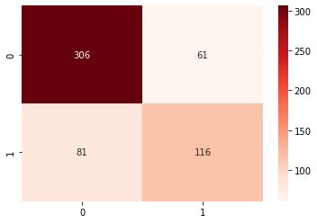

```python
from sklearn.neighbors import KNeighborsClassifier
KNN=KNeighborsClassifier()
KNN.fit(X_train,y_train)
report_performance(KNN)
```

##### Grid Search

```python
# modèle et hyper paramètres
n_neighbors = range(1, 21, 2)
weights = ['uniform', 'distance']
metric = ['euclidean', 'manhattan', 'minkowski']
# Grid search
grid = dict(n_neighbors=n_neighbors,weights=weights,metric=metric)
cv = RepeatedStratifiedKFold(n_splits=10, n_repeats=3, random_state=1)
KNN_gs = GridSearchCV(estimator=KNN, param_grid=grid, n_jobs=-1, cv=cv, scoring='f1',error_score=0)
KNN_grid_result = KNN_gs.fit(X_train_scale, y_train)
# Résultats
print('\nBest params:\n', KNN_grid_result.best_params_)
print('Train score: %.3f' % KNN_grid_result.best_score_)
print('Test score: %.3f' % KNN_grid_result.score(X_test_scale, y_test))
```

```
Best params:
 {'metric': 'euclidean', 'n_neighbors': 5, 'weights': 'uniform'}
Train score: 0.606
Test score: 0.610
```

### Support Vector Machine

```
              precision    recall  f1-score   support

           0       0.80      0.85      0.82       367
           1       0.68      0.61      0.65       197

    accuracy                           0.77       564
   macro avg       0.74      0.73      0.74       564
weighted avg       0.76      0.77      0.76       564
```

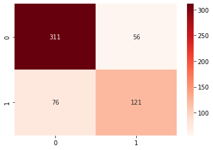

```python
from sklearn.svm import SVC
SVM=SVC()
SVM.fit(X_train,y_train)
report_performance(SVM)
```

##### Grid Search

```python
model = SVC(probability=True)
kernel = ['poly', 'rbf', 'sigmoid','linear']
C = [50, 10, 1.0, 0.1, 0.01]
gamma = ['scale']
# define grid search
grid = dict(kernel=kernel,C=C,gamma=gamma)
cv = RepeatedStratifiedKFold(n_splits=10, n_repeats=3, random_state=1)
SVM_gs = GridSearchCV(estimator=model, param_grid=grid, n_jobs=-1, cv=cv, scoring='f1',error_score=0)
SVM_grid_result = SVM_gs.fit(X_train_scale, y_train)
# Résultats
print('\nBest params:\n', SVM_grid_result.best_params_)
print('Train score: %.3f' % SVM_grid_result.best_score_)
print('Test score: %.3f' % SVM_grid_result.score(X_test_scale, y_test))
```

```
Best params:
 {'C': 1.0, 'gamma': 'scale', 'kernel': 'sigmoid'}
Train score: 0.652
Test score: 0.654
```

```
              precision    recall  f1-score   support

           0       0.81      0.87      0.84       367
           1       0.72      0.61      0.66       197

    accuracy                           0.78       564
   macro avg       0.76      0.74      0.75       564
weighted avg       0.78      0.78      0.78       564
```

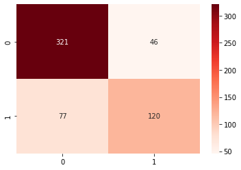

```python
report_performance(SVM_gs)
```

### Comparaison courbes ROC

```python
LR_pred_proba=LR_gs.predict_proba(X_test_scale)[:,1]
fpr_LR, tpr_LR, thresholds_LR = roc_curve(y_test, LR_pred)
roc_auc_LR = auc(fpr_LR, tpr_LR)
```

```python
DT_pred_proba=DT_gs.predict_proba(X_test)[:,1]
fpr_DT, tpr_DT, thresholds_DT = roc_curve(y_test, DT_pred_proba)
roc_auc_DT = auc(fpr_DT, tpr_DT)
```

```python
KNN_pred_proba=KNN_gs.predict_proba(X_test_scale)[:,1]
fpr_KNN, tpr_KNN, thresholds_KNN = roc_curve(y_test, KNN_pred_proba)
roc_auc_KNN = auc(fpr_KNN, tpr_KNN)
```

```python
SVM_pred_proba=SVM_gs.predict_proba(X_test_scale)[:,1]
fpr_SVM, tpr_SVM, thresholds_SVM = roc_curve(y_test, SVM_pred_proba)
roc_auc_SVM = auc(fpr_SVM, tpr_SVM)
```

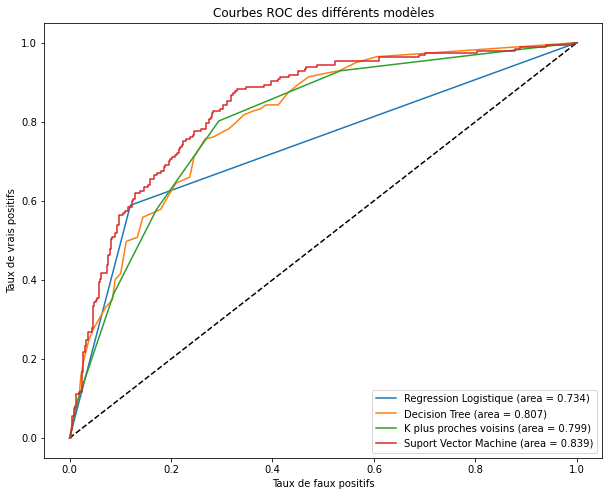

```python
plt.figure(figsize=(10, 8))
plt.plot([0, 1], [0, 1], 'k--')
plt.plot(fpr_LR, tpr_LR, label='Regression Logistique (area = %0.3f)' % roc_auc_LR)
plt.plot(fpr_DT, tpr_DT, label='Decision Tree (area = %0.3f)' % roc_auc_DT)
plt.plot(fpr_KNN, tpr_KNN, label='K plus proches voisins (area = %0.3f)' % roc_auc_KNN)
plt.plot(fpr_SVM, tpr_SVM, label='Suport Vector Machine (area = %0.3f)' % roc_auc_SVM)
plt.xlabel('Taux de faux positifs')
plt.ylabel('Taux de vrais positifs')
plt.title('Courbes ROC des différents modèles')
plt.legend(loc='best')
plt.show()
```